# Minería de datos: Clasificación con árboles de decisión

Autor: Miriam Gimeno Fernandez

Abril 2025

```r
if(!require(tinytex)){
    install.packages('tinytex',repos='http://cran.us.r-project.org')
    library(tinytex)
}
```

# 1 Metodos supervisados

Vamos a explorar el ciclo de vida de un proyecto de minería de datos, centrándonos en un algoritmo de clasificación supervisado: el árbol de decisión. Este modelo es ampliamente utilizado en el ámbito financiero debido a su capacidad para identificar patrones y tomar decisiones basadas en reglas interpretables.

Para ello, trabajaremos con el archivo credit.csv, un conjunto de datos que clasifica a individuos según diversos atributos con el objetivo de determinar su nivel de riesgo de crediticio. La variable objetivo “default” representa la condición de pago de un cliente, donde:

- **1 = “No default”** (clientes que cumplen con sus obligaciones financieras),
- **2 = “Default”** (clientes que han incumplido con sus pagos).

El propósito de este análisis es construir un modelo capaz de predecir el riesgo de crediticio a partir de los atributos disponibles, evaluar su desempeño y extraer reglas interpretables que por ejemplo ayuden a la toma de decisiones en la gestión de crédito.

## 1.1 Análisis descriptivo

Empezaremos realizando un análisis de los datos para tener una idea general.

### 1.1.1 Exploración de la base de datos

```r
# Cargamos los datos
data_credit<-read.csv("./credit.csv",header=T,sep=",")
attach(data_credit)
```

```r
# Obtenemos la esturctura de los datos
structure = str(data_credit)
```

```
## 'data.frame':    1000 obs. of  21 variables:
##  $ checking_balance    : chr  "< 0 DM" "1 - 200 DM" "unknown" "< 0 DM" ...
##  $ months_loan_duration: int  6 48 12 42 24 36 24 36 12 30 ...
##  $ credit_history      : chr  "critical" "repaid" "critical" "repaid" ...
##  $ purpose             : chr  "radio/tv" "radio/tv" "education" "furniture" ...
##  $ amount              : int  1169 5951 2096 7882 4870 9055 2835 6948 3059 5234 ...
##  $ savings_balance     : chr  "unknown" "< 100 DM" "< 100 DM" "< 100 DM" ...
##  $ employment_length   : chr  "> 7 yrs" "1 - 4 yrs" "4 - 7 yrs" "4 - 7 yrs" ...
##  $ installment_rate    : int  4 2 2 2 3 2 3 2 2 4 ...
##  $ personal_status     : chr  "single male" "female" "single male" "single male" ...
##  $ other_debtors       : chr  "none" "none" "none" "guarantor" ...
##  $ residence_history   : int  4 2 3 4 4 4 4 2 4 2 ...
##  $ property            : chr  "real estate" "real estate" "real estate" "building society savings" ...
##  $ age                 : int  67 22 49 45 53 35 53 35 61 28 ...
##  $ installment_plan    : chr  "none" "none" "none" "none" ...
##  $ housing             : chr  "own" "own" "own" "for free" ...
##  $ existing_credits    : int  2 1 1 1 2 1 1 1 1 2 ...
##  $ default             : int  1 2 1 1 2 1 1 1 1 2 ...
##  $ dependents          : int  1 1 2 2 2 2 1 1 1 1 ...
##  $ telephone           : chr  "yes" "none" "none" "none" ...
##  $ foreign_worker      : chr  "yes" "yes" "yes" "yes" ...
##  $ job                 : chr  "skilled employee" "skilled employee" "unskilled resident" "skilled employee" ...
```

Con la anterior función, hemos obtenido la estructura de los datos y como podemos observar, tenemos 1000 registros y 21 variables. Las variables que forman el conjunto de datos son las siguientes:

- **checking_balance**: Estado de la cuenta corriente existente
- **months_loan_duration**: Duración.
- **credit_history**: Historial de crédito.
- **purpose** : Proposito
- **amount**: Monton total de credito.
- **savings_balance** : Cuenta de ahorros
- **employment_length**: Antigüedad de empleo.
- **installment_rate** : Tasa de pago a plazos en porcentaje del ingreso disponible.
- **personal_status**: Estado personal y Sexo.
- **other_debtors**: Otros deudores.
- **residence_history**: Antigüedad de residencia.
- **property**: Propiedad.
- **age**: Edad.
- **installment_plan**: Otros planes de pago.
- **housing**: Alojamiento.
- **existing_credits**: Número de créditos existentes en este banco.
- **default**: 1 = Good, 2 = Bad
- **dependents**: Personas a cargo.
- **telephone**: numero de teléfono de contacto.
- **foreign_worker**: Trabjador extranjero.
- **job**: Trabajo.

La descripción de las variables se han obtenido de la siguiente fuente: https://archive.ics.uci.edu/dataset/144/statlog+german+credit+data

Continuamos con nuestro análisis y para ello vamos a comprobar que no tengamos valores nulos, es decir, campos vacíos con la función “summary”, también obtendremos los dato estadísticos de las variables y como están distribuidos, de esta forma podremos realizar observaciones de las variables numéricas.

```r
summary(data_credit)
```

```
##  checking_balance   months_loan_duration credit_history       purpose
##  Length:1000        Min.   : 4.0         Length:1000        Length:1000
##  Class :character   1st Qu.:12.0         Class :character   Class :character
##  Mode  :character   Median :18.0         Mode  :character   Mode  :character
##                     Mean   :20.9
##                     3rd Qu.:24.0
##                     Max.   :72.0
##      amount      savings_balance    employment_length  installment_rate
##  Min.   :  250   Length:1000        Length:1000        Min.   :1.000
##  1st Qu.: 1366   Class :character   Class :character   1st Qu.:2.000
##  Median : 2320   Mode  :character   Mode  :character   Median :3.000
##  Mean   : 3271                                         Mean   :2.973
##  3rd Qu.: 3972                                         3rd Qu.:4.000
##  Max.   :18424                                         Max.   :4.000
##  personal_status    other_debtors      residence_history   property
##  Length:1000        Length:1000        Min.   :1.000     Length:1000
##  Class :character   Class :character   1st Qu.:2.000     Class :character
##  Mode  :character   Mode  :character   Median :3.000     Mode  :character
##                                        Mean   :2.845
##                                        3rd Qu.:4.000
##                                        Max.   :4.000
##       age        installment_plan     housing          existing_credits
##  Min.   :19.00   Length:1000        Length:1000        Min.   :1.000
##  1st Qu.:27.00   Class :character   Class :character   1st Qu.:1.000
##  Median :33.00   Mode  :character   Mode  :character   Median :1.000
##  Mean   :35.55                                         Mean   :1.407
##  3rd Qu.:42.00                                         3rd Qu.:2.000
##  Max.   :75.00                                         Max.   :4.000
##     default      dependents     telephone         foreign_worker
##  Min.   :1.0   Min.   :1.000   Length:1000        Length:1000
##  1st Qu.:1.0   1st Qu.:1.000   Class :character   Class :character
##  Median :1.0   Median :1.000   Mode  :character   Mode  :character
##  Mean   :1.3   Mean   :1.155
##  3rd Qu.:2.0   3rd Qu.:1.000
##  Max.   :2.0   Max.   :2.000
##      job
##  Length:1000
##  Class :character
##  Mode  :character
##
##
##
```

En el análisis de las variables numéricas, podemos observar varios patrones importantes que pueden influir en la predicción del riesgo de crédito:

**Months Loan Duration (Duración del préstamo):**

Vemos que el rango esta entre 4 y 72 meses y la mediana es de 18 meses, con una media de 20.9 meses. Con estos datos, las observamos que podemos realizar es que la mayoría de los préstamos tienen una duración relativamente corta (alrededor de 18 meses), pero existe una variabilidad significativa con préstamos de hasta 6 años.

**Amount (Cantidad solicitada):**

El rango en esta variable va desde 250 hasta 18,424 DM con una mediana: 2,320 DM y una media de 3,271 DM. Podemos ver que la distribución de la cantidad total de préstamo solicitado, parece estar sesgada hacia valores más altos, lo que indica que algunos clientes solicitan sumas significativamente mayores.

**Installment Rate (Tasa de cuotas)**

En esta variable tenemos un rango de 1 a 4, con mediana de 3 y media de 2.97. Lo que nos indica que la mayoría de clientes tienen una tasa de cuota alta, lo que sugiere una mayor carga financiera mensual.

**Age (Edad):**

En la edad tenemos un rango con un mínimo de 19 años y un máximo de 75, la mediana es de 33 años y la media de 36. Por lo que podemos decir que la mayoria de los clientes están en edad laboral activa, pero también hay una presencia notable de solicitantes mayores.

**Residence History (Historial de residencia)**

El historial de residencia tiene una media de 2.8 esto nos puede indicar la estabilidad habitacional, lo que puede estar relacionado con el capacidad de pago.

**Existing Credits (Créditos existentes)**

La media es de 1.4 lo que indica que la mayoría de los clientes tienen uno o pocos créditos activos.

**Default (Incumplimiento)**

La variable objetivo nos indica una media de 1.3 lo que puede indicar una proporción significativa de clientes con historial de impago.Es clave estudiar la relación entre default y otras variables para entender qué perfiles tienen mayor riesgo de incumplimiento

Continuando con nuestro análisis, vamos a comprobar si hay valores missing.

```r
missing <- data_credit[is.na(data_credit),]
dim(missing)
```

```
## [1]  0 21
```

Observamos que no hay valores missing ni campos vacios, por tanto, no deberemos preparar los datos en este sentido.

Por otro lado, como hemos podido observar en la función “summary” y obteniendo la estructura de los datos, las variables categóricas están clasificadas como “Character”, por lo que vamos a convertirlas al tipo “factor”, ya que para trabajar con modelos de aprendizaje automático, facilitará nuestro análisis y mejorará la eficiencia, así también nos aseguramos de que el modelo interprete correctamente las relaciones entre las categorías.

```r
if(!require(dplyr)){
    install.packages('dplyr', repos='http://cran.us.r-project.org')
    library(dplyr)
}
# Convertir solo las columnas categóricas (character) a factor
data_credit <- data_credit %>% mutate_if(is.character, as.factor)

# Ver estructura después de la conversión
str(data_credit)
```

```
## 'data.frame':    1000 obs. of  21 variables:
##  $ checking_balance    : Factor w/ 4 levels "< 0 DM","> 200 DM",..: 1 3 4 1 1 4 4 3 4 3 ...
##  $ months_loan_duration: int  6 48 12 42 24 36 24 36 12 30 ...
##  $ credit_history      : Factor w/ 5 levels "critical","delayed",..: 1 5 1 5 2 5 5 5 5 1 ...
##  $ purpose             : Factor w/ 10 levels "business","car (new)",..: 8 8 5 6 2 5 6 3 8 2 ...
##  $ amount              : int  1169 5951 2096 7882 4870 9055 2835 6948 3059 5234 ...
##  $ savings_balance     : Factor w/ 5 levels "< 100 DM","> 1000 DM",..: 5 1 1 1 1 5 4 1 2 1 ...
##  $ employment_length   : Factor w/ 5 levels "> 7 yrs","0 - 1 yrs",..: 1 3 4 4 3 3 1 3 4 5 ...
##  $ installment_rate    : int  4 2 2 2 3 2 3 2 2 4 ...
##  $ personal_status     : Factor w/ 4 levels "divorced male",..: 4 2 4 4 4 4 4 4 1 3 ...
##  $ other_debtors       : Factor w/ 3 levels "co-applicant",..: 3 3 3 2 3 3 3 3 3 3 ...
##  $ residence_history   : int  4 2 3 4 4 4 4 2 4 2 ...
##  $ property            : Factor w/ 4 levels "building society savings",..: 3 3 3 1 4 4 1 2 3 2 ...
##  $ age                 : int  67 22 49 45 53 35 53 35 61 28 ...
##  $ installment_plan    : Factor w/ 3 levels "bank","none",..: 2 2 2 2 2 2 2 2 2 2 ...
##  $ housing             : Factor w/ 3 levels "for free","own",..: 2 2 2 1 1 1 2 3 2 2 ...
##  $ existing_credits    : int  2 1 1 1 2 1 1 1 1 2 ...
##  $ default             : int  1 2 1 1 2 1 1 1 1 2 ...
##  $ dependents          : int  1 1 2 2 2 2 1 1 1 1 ...
##  $ telephone           : Factor w/ 2 levels "none","yes": 2 1 1 1 1 2 1 2 1 1 ...
##  $ foreign_worker      : Factor w/ 2 levels "no","yes": 2 2 2 2 2 2 2 2 2 2 ...
##  $ job                 : Factor w/ 4 levels "mangement self-employed",..: 2 2 4 2 2 4 2 1 4 1 ...
```

### 1.1.2 Visualización

Continuamos con nuestro análisis visualizando las variables categóricas que consideramos de mayor interés, ya que la observaciones de las variables numéricas las analizamos cuando obtuvimos los datos estadísticos.

```r
if(!require(ggplot2)){
    install.packages('ggplot2', repos='http://cran.us.r-project.org')
    library(ggplot2)
}
if(!require(ggpubr)){
    install.packages('ggpubr', repos='http://cran.us.r-project.org')
    library(ggpubr)
}
if(!require(grid)){
    install.packages('grid', repos='http://cran.us.r-project.org')
    library(grid)
}
if(!require(gridExtra)){
    install.packages('gridExtra', repos='http://cran.us.r-project.org')
    library(gridExtra)
}
if(!require(C50)){
    install.packages('C50', repos='http://cran.us.r-project.org')
    library(C50)
}
```

Primero vamos a visualizar las variables categóricas

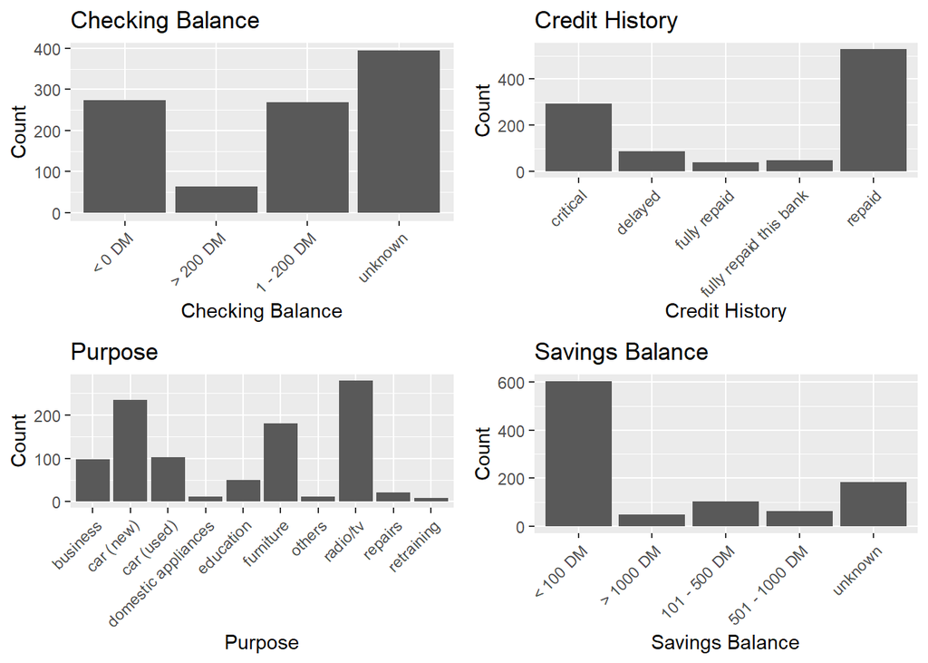

```r
grid.newpage()

# Creamos los gráficos
plotCheckingBalance <- ggplot(data_credit, aes(checking_balance)) +
  geom_bar() +
  labs(x="Checking Balance", y="Count") +
  ggtitle("Checking Balance") +
  theme(axis.text.x = element_text(angle=45, hjust=1))

plotCreditHistory <- ggplot(data_credit, aes(credit_history)) +
  geom_bar() +
  labs(x="Credit History", y="Count") +
  ggtitle("Credit History") +
  theme(axis.text.x = element_text(angle=45, hjust=1))

plotPurpose <- ggplot(data_credit, aes(purpose)) +
  geom_bar() +
  labs(x="Purpose", y="Count") +
  ggtitle("Purpose") +
  theme(axis.text.x = element_text(angle=45, hjust=1))

plotSavingsBalance <- ggplot(data_credit, aes(savings_balance)) +
  geom_bar() +
  labs(x="Savings Balance", y="Count") +
  ggtitle("Savings Balance") +
  theme(axis.text.x = element_text(angle=45, hjust=1))

# Mostramos los gráficos
grid.arrange(plotCheckingBalance, plotCreditHistory, plotPurpose, plotSavingsBalance, ncol=2)
```

Las observaciones que podemos apreciar en los graficos obtenidos son las sigueintes:

**Chequing Balance**:

- La mayoría de cliente tienen un balance de cuenta desconocido y saldos < 0 DM, lo que suguiere una porporción significativa con fondos insuficientes en sus cuentas al momento de solicitar un crédito. Por otro lado también tenemos más o menos la misma proporcion de clientes con saldos entre 1 - 200 DM.

**credit History**:

- La mayoría de los solicitantes tienen un historial de crédito positivo, con la categoría “repaid” siendo la más común. Sin embarog, hay una presencia notable de clientes con historial crítico, lo que podría ser un indicativo de mayor riesgo de impago.

**Purpose**

- La razón más frecuente para solicitar crédito es la compra de radio/TV, seguida por automóviles y muebles.

**Savings Balance**

- La mayoría de los clientes tienen menos de 100 DM en ahorros, lo que podría indicar una baja capacidad de respuesta ante imprevistos financieros.

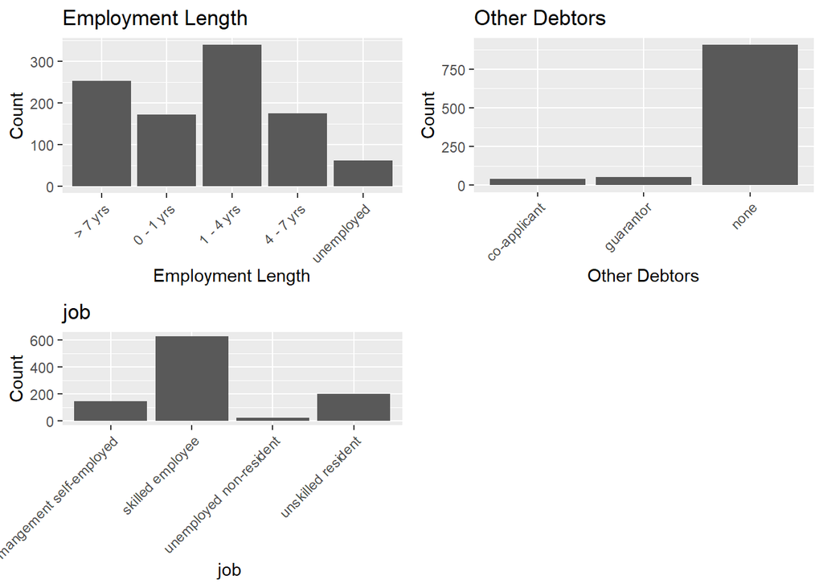

```r
grid.newpage()

plotEmploymentLength <- ggplot(data_credit, aes(employment_length)) +
  geom_bar() +
  labs(x="Employment Length", y="Count") +
  ggtitle("Employment Length")  +
  theme(axis.text.x = element_text(angle=45, hjust=1))

plotOtherDebtors <- ggplot(data_credit, aes(other_debtors)) +
  geom_bar() +
  labs(x="Other Debtors", y="Count") +
  ggtitle("Other Debtors") +
  theme(axis.text.x = element_text(angle=45, hjust=1))

plotjob  <- ggplot(data_credit, aes(job )) +
  geom_bar() +
  labs(x="job ", y="Count") +
  ggtitle("job ") +
  theme(axis.text.x = element_text(angle=45, hjust=1))

# Mostramos los gráficos
grid.arrange(plotEmploymentLength, plotOtherDebtors, plotjob, ncol=2)
```

De estos graficos extraemos las siguientes observaciones:

**Employment Lenght (Antigüedad de trabajo):**

- La mayoría de clientes cuentan con una antigüedad de 1 a 4 años, siguiéndole más de 7 años y de 4 a 7 año. Esto nos sugiere que los clientes que solicitan creditos, tienen una estabilidad laboral lo que puede indicar menos riesgo de impago.

**Other Debtors (Otros deudores):**

La mayoria no tienen otras deudas.

**Job:**

En cuanto a la variable de trabajo podemos ver que categoría que destaca del resto son los empleados calificados o trabajadores cualificados.

Para continuar analizando la distribución de nuestras variables, vamos a representar gráficamente la variable de interés “default” con el resto de algunas de las variables.

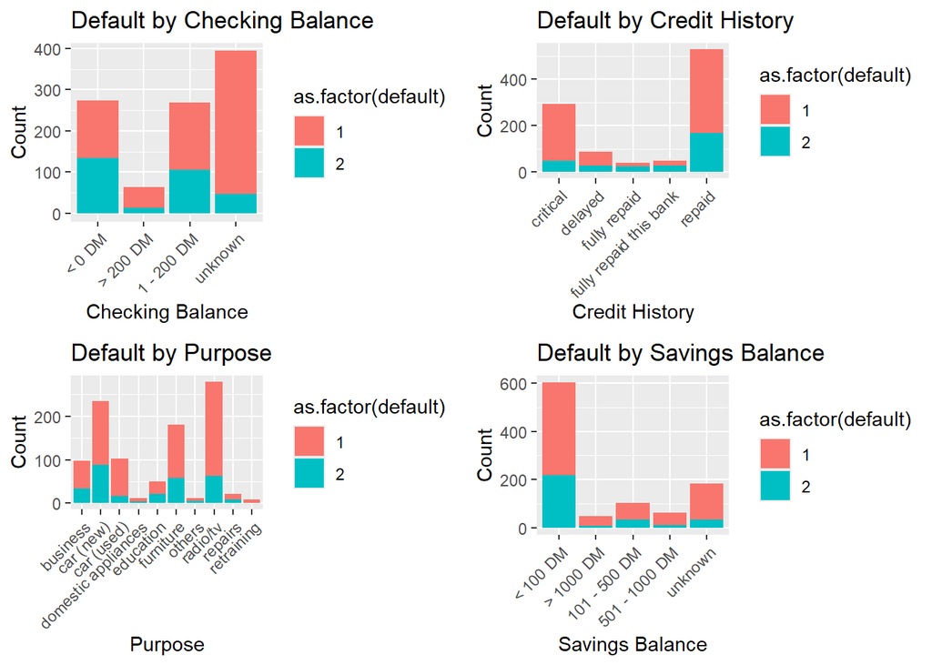

```r
grid.newpage()

# Gráficos
plotCheckingBalance <- ggplot(data_credit, aes(checking_balance, fill= as.factor(default))) +
  geom_bar() +
  labs(x="Checking Balance", y="Count") +
  ggtitle("Default by Checking Balance") +
  theme(axis.text.x = element_text(angle=45, hjust=1))

plotCreditHistory <- ggplot(data_credit, aes(credit_history, fill=as.factor(default))) +
  geom_bar() +
  labs(x="Credit History", y="Count") +
  ggtitle("Default by Credit History") +
  theme(axis.text.x = element_text(angle=45, hjust=1))

plotPurpose <- ggplot(data_credit, aes(purpose, fill=as.factor(default))) +
  geom_bar() +
  labs(x="Purpose", y="Count") +
  ggtitle("Default by Purpose") +
  theme(axis.text.x = element_text(angle=45, hjust=1))

plotSavingsBalance <- ggplot(data_credit, aes(savings_balance, fill=as.factor(default))) +
  geom_bar() +
  labs(x="Savings Balance", y="Count") +
  ggtitle("Default by Savings Balance") +
  theme(axis.text.x = element_text(angle=45, hjust=1))

# Mostramos los gráficos comparativos
grid.arrange(plotCheckingBalance, plotCreditHistory, plotPurpose, plotSavingsBalance, ncol=2)
```

A rasgos generales, podemos observar que el historial crediticio y el saldo en cuenta parecen ser los factores más relevantes para predecir el incumplimiento de pagos. Se aprecia un mayor porcentaje de default = 2 en los clientes con balances < 0 DM, lo que indica que aquellos con problemas de liquidez inicial tienen más probabilidades de incumplir sus obligaciones financieras.

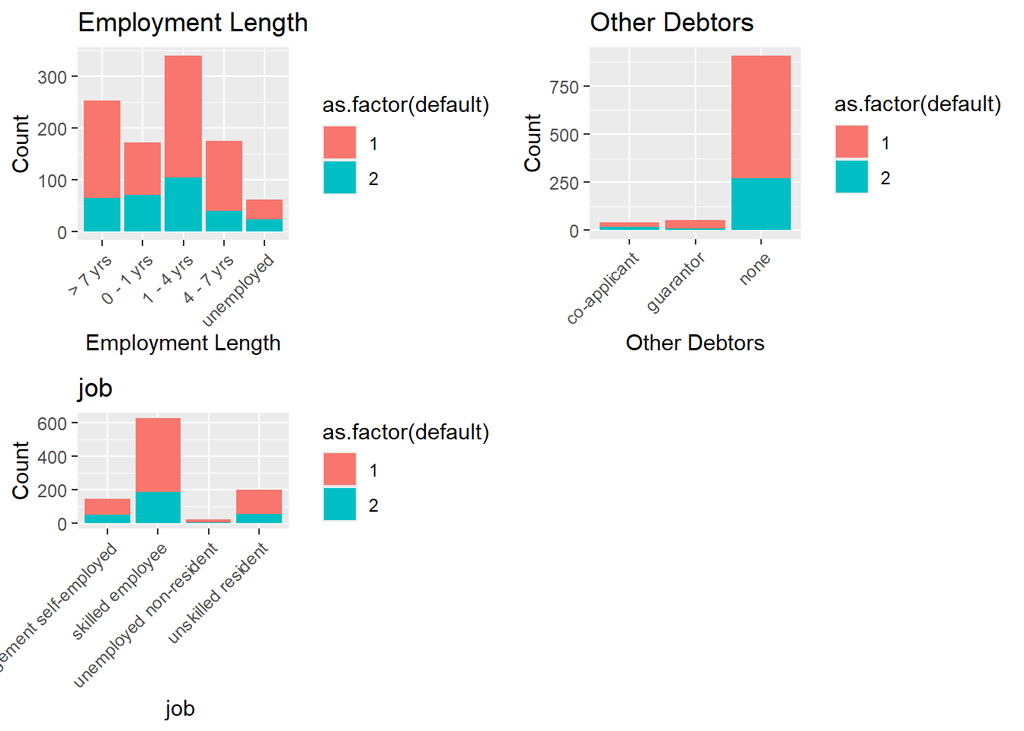

```r
grid.newpage()

plotEmploymentLength <- ggplot(data_credit, aes(employment_length, fill= as.factor(default))) +
  geom_bar() +
  labs(x="Employment Length", y="Count") +
  ggtitle("Employment Length")  +
  theme(axis.text.x = element_text(angle=45, hjust=1))

plotOtherDebtors <- ggplot(data_credit, aes(other_debtors, fill= as.factor(default))) +
  geom_bar() +
  labs(x="Other Debtors", y="Count") +
  ggtitle("Other Debtors") +
  theme(axis.text.x = element_text(angle=45, hjust=1))

plotjob  <- ggplot(data_credit, aes(job, fill= as.factor(default))) +
  geom_bar() +
  labs(x="job ", y="Count") +
  ggtitle("job ") +
  theme(axis.text.x = element_text(angle=45, hjust=1))

# Mostramos los gráficos
grid.arrange(plotEmploymentLength, plotOtherDebtors, plotjob, ncol=2)
```

Continuamos con la relacion entre la varaible Default y algunas de las variables númericas

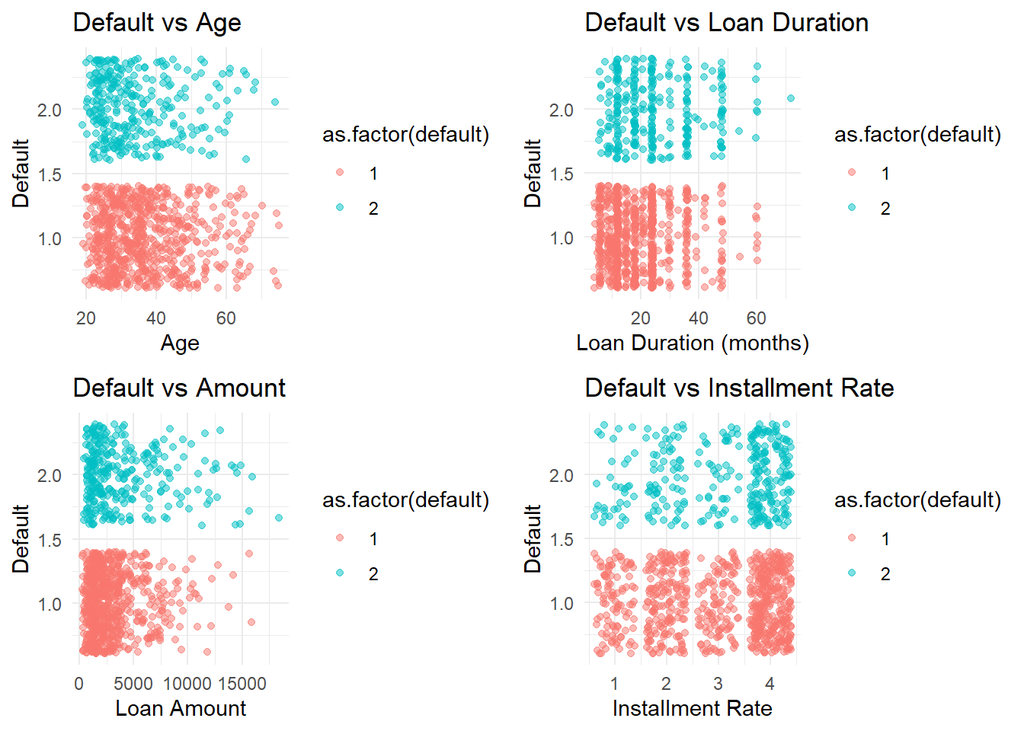

```r
grid.newpage()

# Gráficos de dispersión
plotAge <- ggplot(data_credit, aes(x=age, y=default, color=as.factor(default))) +
  geom_jitter(alpha=0.5) + labs(x="Age", y="Default") + ggtitle("Default vs Age") +
  theme_minimal()

plotLoanDuration <- ggplot(data_credit, aes(x=months_loan_duration, y=default, color=as.factor(default))) +
  geom_jitter(alpha=0.5) + labs(x="Loan Duration (months)", y="Default") + ggtitle("Default vs Loan Duration") +
  theme_minimal()

plotAmount <- ggplot(data_credit, aes(x=amount, y=default, color=as.factor(default))) +
  geom_jitter(alpha=0.5) + labs(x="Loan Amount", y="Default") + ggtitle("Default vs Amount") +
  theme_minimal()

plotInstallment <- ggplot(data_credit, aes(x=installment_rate, y=default, color=as.factor(default))) +
  geom_jitter(alpha=0.5) + labs(x="Installment Rate", y="Default") + ggtitle("Default vs Installment Rate") +
  theme_minimal()

# Mostramos los gráficos
grid.arrange(plotAge, plotLoanDuration, plotAmount, plotInstallment, ncol=2)
```

No hay una variable numérica que por sí sola prediga claramente el incumplimiento de pago, pero algunas muestran ligeras tendencias que podrían ser exploradas con un análisis más profundo.

Edad más joven préstamos más largos y tasa de cuotas mas altas, parecen tener un ligero impacto en el impago, aunque no es una relación totalmente marcada.

Es importante destacar que, en todas las variables y categorías analizadas, la distribución de los datos predomina para Default = 1, lo que indica que la mayoría de los clientes cumplen con sus obligaciones financieras.

### 1.1.3 Análisis de correlación

#### 1.1.3.1 Variables numéricas

Para continuar con nuestro análisis vamos ha realizar un análisis de correlación de las variables numéricas, este análisis nos ayudará a:

Identificar relaciones fuertes entre variables clave como amount, age, months_loan_duration, installment_rate y default. Detectar redundancias en variables altamente correlacionadas (por ejemplo, si dos variables representan información similar). Seleccionar variables relevantes para un modelo de predicción.

Para ello vamos a utilizar la función cor(), esto generará una tabla con los valores de correlación entre todas las variables.

- Valores cercanos a 1 indican un correlación positiva fuerte.
- Valores cercanos a -1 indican una correlación negativa fuerte.
- Valores cercanos a 0 indican que no hay una relación clara.

```r
# variables numéricas
numeric_vars <- data_credit[, sapply(data_credit, is.numeric)]

# Calcular la matriz de correlación
cor_matrix <- cor(numeric_vars, use="complete.obs")

# Ver la matriz de correlación
print(cor_matrix)
```

```
##                      months_loan_duration      amount installment_rate
## months_loan_duration           1.00000000  0.62498420       0.07474882
## amount                         0.62498420  1.00000000      -0.27131570
## installment_rate               0.07474882 -0.27131570       1.00000000
## residence_history              0.03406720  0.02892632       0.04930237
## age                           -0.03613637  0.03271642       0.05826568
## existing_credits              -0.01128360  0.02079455       0.02166874
## default                        0.21492667  0.15473864       0.07240394
## dependents                    -0.02383448  0.01714215      -0.07120694
##                      residence_history         age existing_credits
## months_loan_duration       0.034067202 -0.03613637      -0.01128360
## amount                     0.028926323  0.03271642       0.02079455
## installment_rate           0.049302371  0.05826568       0.02166874
## residence_history          1.000000000  0.26641918       0.08962523
## age                        0.266419184  1.00000000       0.14925358
## existing_credits           0.089625233  0.14925358       1.00000000
## default                    0.002967159 -0.09112741      -0.04573249
## dependents                 0.042643426  0.11820083       0.10966670
##                           default   dependents
## months_loan_duration  0.214926665 -0.023834475
## amount                0.154738641  0.017142154
## installment_rate      0.072403937 -0.071206943
## residence_history     0.002967159  0.042643426
## age                  -0.091127409  0.118200833
## existing_credits     -0.045732489  0.109666700
## default               1.000000000 -0.003014853
## dependents           -0.003014853  1.000000000
```

#### 1.1.3.2 visualicación de la correlacion con heatmap

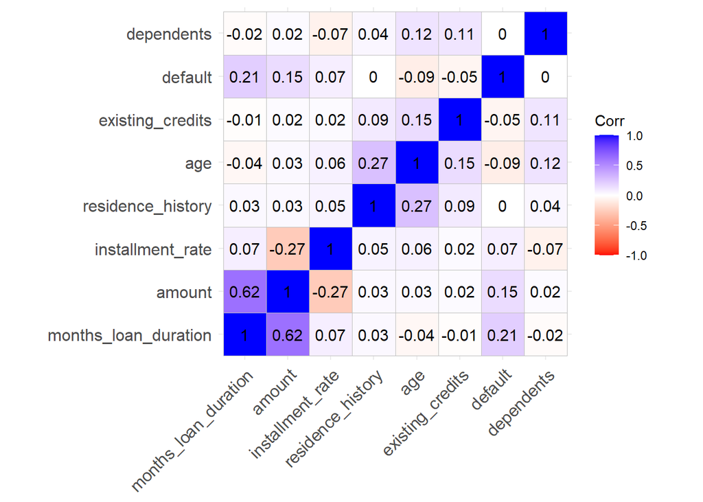

```r
options(repos = c(CRAN = "https://cloud.r-project.org"))
install.packages("ggcorrplot")
library(ggcorrplot)
ggcorrplot(cor_matrix, lab = TRUE, colors = c("red", "white", "blue"))
```

Observaciones principales:

**1. Correlación de “default” con otras variables**

Esto sugiere que ninguna variable numérica por sí sola explica fuertemente el riesgo de incumplimiento. Será necesario usar varios factores combinados (modelo multivariable).

**2. Relación fuerte entre algunas variables**

- months_loan_duration y amount: 0.62
- Alta correlación → mientras más largo es el préstamo, mayor suele ser el monto.
- installment_rate y amount: -0.27
- Correlación negativa → cuotas más altas tienden a asociarse con préstamos más pequeños (posiblemente porque el plazo es más corto).

**3. Variables casi independientes**

- age, residence_history, dependents, y existing_credits tienen correlaciones muy bajas con casi todas las demás.

Esto sugiere que aportan información única y podrían ser útiles en modelos predictivos a pesar de la baja correlación individual con default.

#### 1.1.3.3 Variables Categóricas.

Para analizar la relación entre las variables categóricas y la variable objetivo (default), se utilizaran tablas de contingencia junto con el test de independencia chi-cuadrado.

Este enfoque permite evaluar si existe una asociación estadísticamente significativa entre cada variable categórica (como el tipo de trabajo, estado civil, historial crediticio, etc.) y la probabilidad de incumplimiento del crédito.

Las tablas de contingencia muestran la distribución conjunta de las categorías, mientras que el test de chi-cuadrado evalúa si las diferencias observadas podrían deberse al azar.

Un valor p inferior a 0.05 se considera evidencia suficiente para rechazar la hipótesis nula de independencia, indicando que la variable categórica está asociada significativamente con el riesgo de crédito (default).

```r
# Creamos una lista para almacenar los resultados
results <- data.frame(
  Variable = character(),
  p_value = numeric(),
  Significativo = character(),
  stringsAsFactors = FALSE
)


# 2. Identificamos las variables categóricas
cat_vars <- names(data_credit)[sapply(data_credit, is.factor)]
cat_vars <- setdiff(cat_vars, "default")  # Excluye la variable objetivo

# 3. Aplicamos la tabla de contingencia y test chi-cuadrado para cada variable
for (var in cat_vars) {
  cat("\nVariable:", var, "\n")

  # Crear tabla de contingencia
  tbl <- table(data_credit[[var]], data_credit$default)
  print(tbl)

  # Test chi-cuadrado
  test <- chisq.test(tbl)
  cat("Valor p:", test$p.value, "\n")

  if (test$p.value < 0.05) {
    cat("→ Asociación significativa con 'default' (p < 0.05)\n")
  } else {
    cat("→ No significativa (p ≥ 0.05)\n")
  }
}
```

```
##
## Variable: checking_balance
##
##                1   2
##   < 0 DM     139 135
##   > 200 DM    49  14
##   1 - 200 DM 164 105
##   unknown    348  46
## Valor p: 1.218902e-26
## → Asociación significativa con 'default' (p < 0.05)
##
## Variable: credit_history
##
##                            1   2
##   critical               243  50
##   delayed                 60  28
##   fully repaid            15  25
##   fully repaid this bank  21  28
##   repaid                 361 169
## Valor p: 1.279187e-12
## → Asociación significativa con 'default' (p < 0.05)
##
## Variable: purpose
##
##                         1   2
##   business             63  34
##   car (new)           145  89
##   car (used)           86  17
##   domestic appliances   8   4
##   education            28  22
##   furniture           123  58
##   others                7   5
##   radio/tv            218  62
##   repairs              14   8
##   retraining            8   1
```

```
## Valor p: 0.0001157491
## → Asociación significativa con 'default' (p < 0.05)
##
## Variable: savings_balance
##
##                   1   2
##   < 100 DM      386 217
##   > 1000 DM      42   6
##   101 - 500 DM   69  34
##   501 - 1000 DM  52  11
##   unknown       151  32
## Valor p: 2.761214e-07
## → Asociación significativa con 'default' (p < 0.05)
##
## Variable: employment_length
##
##                1   2
##   > 7 yrs    189  64
##   0 - 1 yrs  102  70
##   1 - 4 yrs  235 104
##   4 - 7 yrs  135  39
##   unemployed  39  23
## Valor p: 0.001045452
## → Asociación significativa con 'default' (p < 0.05)
##
## Variable: personal_status
##
##                   1   2
##   divorced male  30  20
##   female        201 109
##   married male   67  25
##   single male   402 146
## Valor p: 0.02223801
## → Asociación significativa con 'default' (p < 0.05)
##
## Variable: other_debtors
##
##                  1   2
##   co-applicant  23  18
##   guarantor     42  10
```

[output cut: 42 more lines]

```
##         1   2
##   no   33   4
##   yes 667 296
## Valor p: 0.01583075
## → Asociación significativa con 'default' (p < 0.05)
##
## Variable: job
##
##                             1   2
##   mangement self-employed  97  51
##   skilled employee        444 186
##   unemployed non-resident  15   7
##   unskilled resident      144  56
## Valor p: 0.5965816
## → No significativa (p ≥ 0.05)
```

```r
# Vemos los resultados
print(results)
```

```
## [1] Variable      p_value       Significativo
## <0 rows> (or 0-length row.names)
```

Conclusión general:

La mayoría de las variables categóricas analizadas muestran asociaciones significativas con el estado de default, lo que sugiere que deberían ser consideradas en modelos predictivos.

Sin embargo, variables como telephone y job no muestran una relación estadísticamente significativa con el resultado, y podrían tener menos relevancia predictiva, pero las mantenderemos en nuestro modelo.

## 1.2 Árbol de decisión (20%)

### 1.2.1 Preparación de datos para el modelo.

Para la futura evaluación del árbol de decisión, es necesario dividir el conjunto de datos en un conjunto de entrenamiento y un conjunto de prueba. El conjunto de entrenamiento es el subconjunto del conjunto original de datos utilizado para construir un primer modelo; y el conjunto de prueba, el subconjunto del conjunto original de datos utilizado para evaluar la calidad del modelo.

```r
set.seed(123) # Fijamos semilla para reproducibilidad

y <- data_credit[,17] # Columna variable objetivo "Default"
x <- data_credit[, setdiff(1:21, 17)]
 # Resto de variables

# Defininos la proporción del split
split_prop <- 3
indexes <- sample(1:nrow(data_credit), size = floor(((split_prop-1)/split_prop) * nrow(data_credit)))

# Conjuntos de entrenamiento y prueba
trainX <- x[indexes, ]
trainy <- y[indexes]
testX <- x[-indexes, ]
testy <- y[-indexes]
```

Vamos a efectuar un análisis de los datos mínimo para asegurarnos de evitar un sesgo en el modelo, aseguramos que la proporción de clientes que incumplen (default = 2) sea similar en el conjunto de entrenamiento y prueba.

```r
summary(trainX)
```

```
##    checking_balance months_loan_duration                credit_history
##  < 0 DM    :182     Min.   : 4.00        critical              :192
##  > 200 DM  : 42     1st Qu.:12.00        delayed               : 51
##  1 - 200 DM:185     Median :18.00        fully repaid          : 24
##  unknown   :257     Mean   :20.54        fully repaid this bank: 36
##                     3rd Qu.:24.00        repaid                :363
##                     Max.   :60.00
##
##        purpose        amount           savings_balance  employment_length
##  radio/tv  :187   Min.   :  250   < 100 DM     :410    > 7 yrs   :166
##  car (new) :151   1st Qu.: 1358   > 1000 DM    : 30    0 - 1 yrs :112
##  furniture :118   Median : 2278   101 - 500 DM : 66    1 - 4 yrs :231
##  car (used): 75   Mean   : 3262   501 - 1000 DM: 43    4 - 7 yrs :114
##  business  : 68   3rd Qu.: 3927   unknown      :117    unemployed: 43
##  education : 34   Max.   :18424
##  (Other)   : 33
##  installment_rate      personal_status      other_debtors residence_history
##  Min.   :1.000    divorced male: 35    co-applicant: 24   Min.   :1.000
##  1st Qu.:2.000    female       :208    guarantor   : 34   1st Qu.:2.000
##  Median :3.000    married male : 66    none        :608   Median :3.000
##  Mean   :2.965    single male  :357                       Mean   :2.835
##  3rd Qu.:4.000                                            3rd Qu.:4.000
##  Max.   :4.000                                            Max.   :4.000
##
##                      property        age        installment_plan     housing
##  building society savings:149   Min.   :19.00   bank  : 99       for free: 80
##  other                   :222   1st Qu.:27.00   none  :540       own     :469
##  real estate             :194   Median :33.00   stores: 27       rent    :117
##  unknown/none            :101   Mean   :35.84
##                                 3rd Qu.:42.00
##                                 Max.   :75.00
##
##  existing_credits   dependents    telephone  foreign_worker
##  Min.   :1.000    Min.   :1.000   none:390   no : 24
##  1st Qu.:1.000    1st Qu.:1.000   yes :276   yes:642
##  Median :1.000    Median :1.000
##  Mean   :1.399    Mean   :1.156
##  3rd Qu.:2.000    3rd Qu.:1.000
##  Max.   :4.000    Max.   :2.000
##
##                       job
##  mangement self-employed: 98
##  skilled employee       :413
##  unemployed non-resident: 17
##  unskilled resident     :138
##
##
##
```

```r
summary(trainy)
```

```
##    Min. 1st Qu.  Median    Mean 3rd Qu.    Max.
##   1.000   1.000   1.000   1.296   2.000   2.000
```

```r
summary(testX)
```

```
##    checking_balance months_loan_duration                credit_history
##  < 0 DM    : 92     Min.   : 4.00        critical              :101
##  > 200 DM  : 21     1st Qu.:12.00        delayed               : 37
##  1 - 200 DM: 84     Median :18.00        fully repaid          : 16
##  unknown   :137     Mean   :21.63        fully repaid this bank: 13
##                     3rd Qu.:24.00        repaid                :167
##                     Max.   :72.00
##
##        purpose       amount           savings_balance  employment_length
##  radio/tv  :93   Min.   :  362   < 100 DM     :193    > 7 yrs   : 87
##  car (new) :83   1st Qu.: 1389   > 1000 DM    : 18    0 - 1 yrs : 60
##  furniture :63   Median : 2372   101 - 500 DM : 37    1 - 4 yrs :108
##  business  :29   Mean   : 3291   501 - 1000 DM: 20    4 - 7 yrs : 60
##  car (used):28   3rd Qu.: 4012   unknown      : 66    unemployed: 19
##  education :16   Max.   :15653
##  (Other)   :22
##  installment_rate      personal_status      other_debtors residence_history
##  Min.   :1.000    divorced male: 15    co-applicant: 17   Min.   :1.000
##  1st Qu.:2.000    female       :102    guarantor   : 18   1st Qu.:2.000
##  Median :3.000    married male : 26    none        :299   Median :3.000
##  Mean   :2.988    single male  :191                       Mean   :2.865
##  3rd Qu.:4.000                                            3rd Qu.:4.000
##  Max.   :4.000                                            Max.   :4.000
##
##                      property        age        installment_plan     housing
##  building society savings: 83   Min.   :20.00   bank  : 40       for free: 28
##  other                   :110   1st Qu.:26.00   none  :274       own     :244
##  real estate             : 88   Median :32.50   stores: 20       rent    : 62
##  unknown/none            : 53   Mean   :34.96
##                                 3rd Qu.:41.75
##                                 Max.   :74.00
##
##  existing_credits   dependents    telephone  foreign_worker
##  Min.   :1.000    Min.   :1.000   none:206   no : 13
##  1st Qu.:1.000    1st Qu.:1.000   yes :128   yes:321
##  Median :1.000    Median :1.000
##  Mean   :1.422    Mean   :1.153
##  3rd Qu.:2.000    3rd Qu.:1.000
##  Max.   :4.000    Max.   :2.000
##
##                       job
##  mangement self-employed: 50
##  skilled employee       :217
##  unemployed non-resident:  5
##  unskilled resident     : 62
##
##
##
```

```r
summary(testy)
```

```
##    Min. 1st Qu.  Median    Mean 3rd Qu.    Max.
##   1.000   1.000   1.000   1.308   2.000   2.000
```

Equilibrio en la división de datos:

La proporción de clientes con Default = 1 (sin impago) y Default = 2 (impago) se mantiene relativamente constante entre el conjunto de entrenamiento (Mean = 1.296) y prueba (Mean = 1.308). Esto indica que la división de los datos no introdujo un sesgo significativo, lo que garantiza una evaluación más confiable del modelo

Validación de la muesta:

Las proporciones entre entrenamiento y prueba son similares, lo que sugiere que el modelo de árbol de decisión tendrá una evaluación coherente. Las categorías de variables importantes se distribuyen de manera equilibrada, lo que permitirá una predicción más precisa. No se observan valores extremos que puedan distorsionar el análisis, por lo que los datos son adecuados para entrenar el modelo.

### 1.2.2 Creación del modelo

Creamos el árbol de decisión usando los datos de entrenamiento.

```r
trainy <-  as.factor(trainy)
model <- C50::C5.0(trainX, trainy,rules=TRUE )
summary(model)
```

```
##
## Call:
## C5.0.default(x = trainX, y = trainy, rules = TRUE)
##
##
## C5.0 [Release 2.07 GPL Edition]      Tue Jun 10 13:01:49 2025
## -------------------------------
##
## Class specified by attribute `outcome'
##
## Read 666 cases (21 attributes) from undefined.data
##
## Rules:
##
## Rule 1: (257/30, lift 1.3)
##  checking_balance = unknown
##  ->  class 1  [0.880]
##
## Rule 2: (606/159, lift 1.0)
##  credit_history in {critical, delayed, repaid}
##  ->  class 1  [0.737]
##
## Rule 3: (23/2, lift 3.0)
##  checking_balance in {< 0 DM, 1 - 200 DM}
##  months_loan_duration > 47
##  savings_balance = < 100 DM
##  ->  class 2  [0.880]
##
## Rule 4: (5, lift 2.9)
##  checking_balance in {< 0 DM, > 200 DM, 1 - 200 DM}
##  months_loan_duration > 16
##  amount <= 1546
##  savings_balance = unknown
##  ->  class 2  [0.857]
##
## Rule 5: (64/16, lift 2.5)
##  checking_balance in {< 0 DM, > 200 DM, 1 - 200 DM}
##  months_loan_duration > 16
##  savings_balance = < 100 DM
##  installment_rate > 3
```

[output cut: 23 more lines]

```
##     108    89    (b): class 2
##
##
##  Attribute usage:
##
##   98.80% credit_history
##   56.76% checking_balance
##   12.46% months_loan_duration
##   12.46% savings_balance
##    9.61% installment_rate
##    9.61% residence_history
##    0.75% amount
##
##
## Time: 0.0 secs
```

**Interpretación de lo datos obtenidos**

Variables más importantes:

- Historial crediticio (Credit History): Es la variable con mayor peso en la clasificación (98.80% de uso), lo que indica que es el predictor más relevante para determinar si un cliente incumplirá o no.
- Saldo en cuenta (Checking Balance): Influye en 56.76% de los casos, mostrando que la liquidez inicial del cliente es un factor clave.
- Duración del préstamo (Months Loan Duration): Se usa en 12.46% de los casos, lo que sugiere que plazos más largos pueden influir en el incumplimiento.
- Ahorros (Savings Balance): También tiene un impacto del 12.46%, lo que indica que los clientes con menores ahorros tienen mayor riesgo.

Evaluación del modelo:

El modelo tiene una tasa de error del 21.0% en el conjunto de entrenamiento, con 140 errores de clasificación en 666 casos. Esto indica que hay margen de mejora, quizás ajustando los parámetros del modelo o probando con diferentes criterios de selección de variables.

Matriz de confusión:

- Precisión para clase 1 (No Default): 93.2% (437/469).
- Precisión para clase 2 (Default): 45.2% (89/197).

El modelo tiene mejor desempeño prediciendo clientes que NO incumplen, pero podría mejorar en la detección de clientes en riesgo de impago.

A continuación mostramos el árbol obtenido:

```r
if(!require(grid)){
    install.packages('grid', repos='http://cran.us.r-project.org')
    library(grid)
}
```

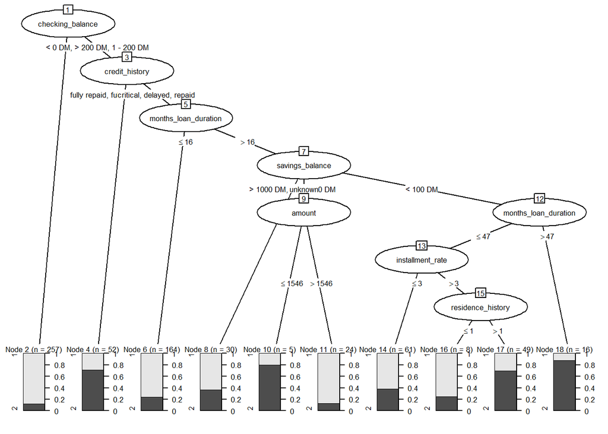

```r
model <- C50::C5.0(trainX, trainy)
plot(model,gp = gpar(fontsize = 6.4))
```

## 1.3 Reglas del árbol de decisión (15%)

El modelo de C5.0 ha generado 6 reglas de decisión con diferentes criterios para clasificar a los clientes entre Default = 1 (sin incumplimiento, NO default) y Default = 2 (con incumplimiento, Default). A continuación, analizamos cada una:

**Regla 1: (257 observaciones, 30 errores):**

- Condición: **checking_balance = unknown**. Si el saldo en cuenta es “unknown”, el cliente se clasifica como Default = 1 con una confianza del 88%.
- Interpretación: Si el saldo en la cuenta corriente es desconocido, lo más probable es que la persona cumpla con el crédito.

**Regla 2: (606 observaciones, 159 errores):**

- Condición: **credit_history es critical, delayed, o repaid**. Si el historial crediticio es “critical”, “delayed” o “repaid”, el modelo predice Default = 1 con 73.7% de confianza.
- Interpretación: Aun si el historial de crédito incluye demoras o problemas previos, en muchos casos la persona igual no incumple.

**Regla 3: (23 observaciones, 2 errores):**

- Condición: **checking_balance en {< 0 DM, 1 - 200 DM}** **months_loan_duration > 47** **savings_balance = < 100 DM**

  Si el saldo en cuenta es menor a 200 DM, la duración del préstamo supera los 47 meses, y los ahorros son menores a 100 DM, el cliente se clasifica como Default = 2 con 88% de confianza.
- Interpretación: Personas con bajo saldo en cuenta y en ahorros, y préstamos largos, son altamente propensas a incumplir.

**Regla 4: (5 observaciones):**

- Condición: **checking_balance {< 0 DM, > 200 DM, 1 - 200 DM}** **months_loan_duration > 16** **amount <= 1546** **savings_balance = unknown**

  Si el saldo en cuenta es menor o mayor a 200 DM y está entre 1 y 200 DM, el préstamo dura más de 16 meses, el monto es menor a 1546 DM, y el saldo de ahorros es desconocido, se clasifica como Default = 2 con 85.7% de confianza.
- Interpretación: Aunque esta regla cubre pocos casos, su precisión es alta, lo que sugiere que la combinación de duración del prestamo y desconocimiento de ahorros es un factor determinante en el riesgo de impago.

**Regla 5: (64 observaciones, 16 errores):**

- Condición: **checking_balance {< 0 DM, > 200 DM, 1 - 200 DM}** **months_loan_duration > 16** **savings_balance = < 100 DM** **installment_rate > 3** **residence_history > 1**

  Si el saldo en cuenta es menor o mayor a 200 DM y está entre 1 y 200 DM, el préstamo dura más de 16 meses, los ahorros son menores a 100 DM, la tasa de cuotas es mayor a 3 y la historia de residencia es mayor a 1, se clasifica como Default = 2 con 74.2% de confianza.
- Interpretación: Los clientes con mayor tasa de cuotas y cambios en la residencia pueden tener mayor presión económica, lo que aumenta el riesgo de incumplimiento.

**Regla 6: (52 observaciones, 15 errores)**

- Condición: **checking_balance {< 0 DM, > 200 DM, 1 - 200 DM}** **credit_history en {fully repaid, fully repaid this bank}**

  Si el saldo en cuenta es menor o mayor a 200 DM y está entre 1 y 200 DM y el historial crediticio es “fully repaid” o “fully repaid this bank”, se clasifica como Default = 2 con 70.4% de confianza.
- Interpretación: A pesar de haber pagado bien antes, si el saldo es bajo, hay un grupo de personas que igual terminan incumpliendo.

## 1.4 Bondad de ajuste (10%)

Para evaluar si nuestro modelo de árbol de decisión es suficientemente bueno, realizaremos predicciones sobre el conjunto de prueba (testX, testy) y analizaremos la matriz de confusión para identificar los tipos de errores.

```r
predicted_model <- predict( model, testX, type="class" )
print(sprintf("La precisión del árbol es: %.4f %%",100*sum(predicted_model == testy) / length(predicted_model)))
```

```
## [1] "La precisión del árbol es: 72.7545 %"
```

```r
# Realizamos la matriz de confusion

# Generamos la matriz de confusión
conf_matrix <- table(testy,Predicted=predicted_model)

# Mostramos la matriz de confusión
print(conf_matrix)
```

```
##      Predicted
## testy   1   2
##     1 210  21
##     2  70  33
```

El modelo C5.0 ha obtenido una precisión del 72.75% en el conjunto de prueba, tal y como podemos ver en la predicción.

Ahora vamos a interpretar los datos obtenidos en la matriz de confusión.

Casos correctamente clasificados: + 210 clientes que NO incumplen fueron correctamente identificados como Default = 1. + 33 clientes que sí incumplen fueron correctamente clasificados como Default = 2.

Errores de clasificación: + 21 clientes fueron clasificados incorrectamente como default, cuando en realidad sí cumplen sus pagos (falsos positivos). + 70 clientes fueron clasificados erróneamente como no default, cuando en realidad sí incumplen pagos (falsos negativos).

**Evaluación de la calidad del modelo**

- **Precisión general:** 72.75% significa que el modelo hace una buena clasificación, pero aún tiene margen de mejora.
- **Falsos negativos (70 errores):** Este es el problema más importante, porque significa que el modelo no identifica correctamente muchos clientes en riesgo de impago. En un contexto financiero, estos errores pueden ser críticos, ya que llevarían a conceder créditos a clientes que probablemente no cumplirán con sus pagos.
- **Falsos positivos (21 errores):** Este error es menos grave, ya que solo representa clientes que sí cumplen, pero el modelo los marcó como de riesgo. Si el modelo fuera usado para evaluar préstamos, esto podría hacer que algunos clientes solventes sean rechazados innecesariamente.

**¿Es el modelo suficientemente bueno para usarlo?**

Pros del modelo:

- Buena precisión general (72.75%).
- Predice bien los clientes sin riesgo financiero (210 correctos en Default = 1).

Contras y oportunidades de mejora:

- Alta tasa de falsos negativos (70 errores) → Necesitamos mejorar la detección de clientes en riesgo.
- Quizá ajustar hiperparámetros o probar otro modelo como randomForest para reducir errores.

Conclusión: El modelo tiene una precisión aceptable pero necesita mejorar la detección de incumplimientos. Para una aplicación real, sería recomendable ajustarlo antes de usarlo directamente para decisiones financieras ya que correríamos el riesgo de conceder créditos a clientes que en realidad tienen un riesgo de impago.

## 1.5 Árboles de decisión complementarios (10%)

Para mejorar el rendimiento del modelo C5.0, vamos a utlizar otro enfoque probando las **variaciones que nos ofrece el paquete C5.0** para analizar cómo afectan a la creación de los árboles generados. Para ello vamos a incorporar **“Boosting”** donde cada “trial” (ensayo) construye un nuevo árbol corrigiendo errores del anterior.

```r
# Generamos el modelo
modelo2 <- C50::C5.0(trainX, trainy, trials = 10)
predicted_model2 <- predict( modelo2, testX, type="class" )
print(sprintf("La precisión del árbol es: %.4f %%",100*sum(predicted_model2 == testy) / length(predicted_model2)))
```

```
## [1] "La precisión del árbol es: 75.4491 %"
```

```r
# Mostramos la matriz de confusión
mat_conf<-table(testy,Predicted=predicted_model2)
mat_conf
```

```
##      Predicted
## testy   1   2
##     1 209  22
##     2  60  43
```

Comparando con el anterior modelo, vemos que ha mejorado la precisión de un 72.75% a un 75%. Por otro lado, en cuanto a la clasificación de casos correctos como default = 1 vemos que ha variado levemente de 210 a 209, sin embargo a mejorado la clasificación para default = 2 clasificando correctos 43 e incorrectos 60, mejorando en 10 respecto al anterior modelo.

Vamos a modificar “Trials” para comprar si ampliando se produce una mejora en el modelo

```r
# Generamos el modelo
modelo2 <- C50::C5.0(trainX, trainy, trials = 100)
predicted_model2 <- predict( modelo2, testX, type="class" )
print(sprintf("La precisión del árbol es: %.4f %%",100*sum(predicted_model2 == testy) / length(predicted_model2)))
```

```
## [1] "La precisión del árbol es: 76.0479 %"
```

```r
# Mostramos la matriz de confusión
mat_conf<-table(testy,Predicted=predicted_model2)
mat_conf
```

```
##      Predicted
## testy   1   2
##     1 208  23
##     2  57  46
```

Como podemos comprobar a mejorado la precisión y clasificación correcta de default = 2, aun asi continúa sin tener mucha precisión, teniendo un alto numero de clientes mal clasificados para default = 2.

Ahora vamos a comprobar la precisión del modelo c5.0 con **validacion cruzada**, es validación reduce la varianza en la clasificación al probar distintos subconjuntos.

```r
if(!require(caret)){
    install.packages('caret', repos='http://cran.us.r-project.org')
    library(caret)
}
# Creamos el dataframe combinando los predictores con la variable objetivo
train.data <- as.data.frame(cbind(trainX, default = trainy))

# Convertimos la variable objetivo en factor para clasificación
train.data$default <- as.factor(train.data$default)
```

```r
# Configuramos validación cruzada
ctrl <- trainControl(method = "cv", number = 10)

# Definimos hiperparámetros para permitir boosting
tuneGrid <- expand.grid(.trials = 10, .model = "tree", .winnow = FALSE)

# Entrenamos el modelo con validación cruzada y boosting
modelo_cv <- train(default ~ ., data = train.data, method = "C5.0", trControl = ctrl, tuneGrid = tuneGrid)

# Mostramos resultados del modelo
print(modelo_cv)
```

```
## C5.0
##
## 666 samples
##  20 predictor
##   2 classes: '1', '2'
##
## No pre-processing
## Resampling: Cross-Validated (10 fold)
## Summary of sample sizes: 599, 599, 599, 599, 599, 599, ...
## Resampling results:
##
##   Accuracy  Kappa
##   0.72821   0.2896264
##
## Tuning parameter 'trials' was held constant at a value of 10
## Tuning
##  parameter 'model' was held constant at a value of tree
## Tuning
##  parameter 'winnow' was held constant at a value of FALSE
```

```r
pred_cv <- predict(modelo_cv, testX)
conf_matrix_cv <- table(testy, pred_cv)

accuracy_cv <- sum(diag(conf_matrix_cv)) / sum(conf_matrix_cv)
print(paste("Precisión del modelo con validación cruzada:", round(accuracy_cv * 100, 2), "%"))
```

```
## [1] "Precisión del modelo con validación cruzada: 73.65 %"
```

```r
print(conf_matrix_cv)
```

```
##      pred_cv
## testy   1   2
##     1 199  32
##     2  56  47
```

Como podemos observar el modelo no ha tenido mejoras.

Ahora vamos a probar a realizar **“purning” (poda)**, el cual elimina ramas inncesarias del arbol, mejorando su capacidad de generación, para ello vamos a realizar la implementación con (rpart).

```r
if(!require(rpart)){
    install.packages('rpart', repos='http://cran.us.r-project.org')
    library(rpart)
}
```

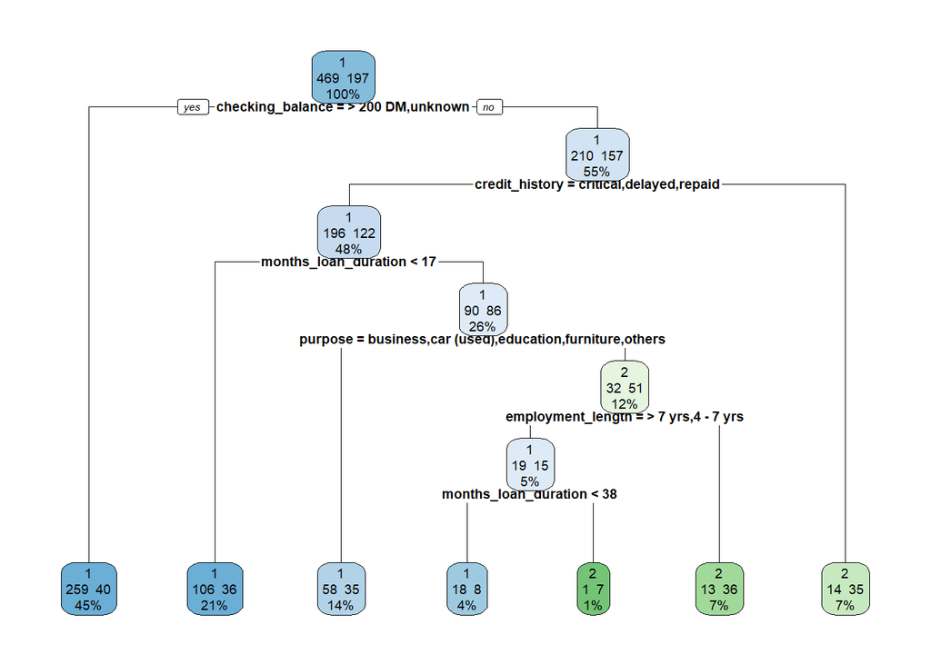

```r
library(rpart.plot)
# Crear modelo de árbol con rpart
modelo_rpart <- rpart(default ~ ., data = train.data, method = "class", control = rpart.control(cp = 0.01))

# Aplicar poda para simplificar el árbol
modelo_podado <- prune(modelo_rpart, cp = 0.02)

# Visualizar árbol podado
rpart.plot(modelo_podado, type = 2, extra = 101, cex = 0.6)
```

```r
pred_rpart <- predict(modelo_rpart, testX)
pred_rpart <- predict(modelo_rpart, testX, type = "class")  # Asegurar predicción de clases
pred_rpart <- as.vector(pred_rpart)  # Convertir a vector
conf_matrix_rpart <- table(testy, pred_rpart)

accuracy_rpart <- sum(diag(conf_matrix_rpart)) / sum(conf_matrix_rpart)
print(paste("Precisión del modelo:", round(accuracy_rpart * 100, 2), "%"))
```

```
## [1] "Precisión del modelo: 74.25 %"
```

```r
print(conf_matrix_rpart)
```

```
##      pred_rpart
## testy   1   2
##     1 198  33
##     2  53  50
```

Tampoco mejora el modelo.

Vamos a comprobar si podemos mejorar el rendimiento del modelo C5.0, para ello vamos a probar **Random Forest**, este modelo utiliza múltiples árboles de decisión para mejorar la precisión.

```r
if(!require(randomForest)){
  install.packages('randomForest',repos='http://cran.us.r-project.org')
  library(randomForest)
}
if(!require(iml)){
  install.packages('iml', repos='http://cran.us.r-project.org')
  library(iml)
}
set.seed(123)
# Entrenamos el modelo Random Forest
X <- train.data[, setdiff(names(train.data), "default")]  # Excluir la variable objetivo
y <- train.data$default  # Definir la variable objetivo

train.data$default <- as.factor(train.data$default)
rf <- randomForest(default ~ ., data = train.data, ntree = 500)
```

Para medir la importancia de cada variable para las predicciones del modelo, vamos a mostrar gráficamente las variables que tienen mayor impacto en la clasificación con las siguientes lineas de codigo:

```r
predictor <- Predictor$new(rf, data = X, y = y)
imp <- FeatureImp$new(predictor, loss = "ce")  # "ce" es la cross-entropy para clasificación
```

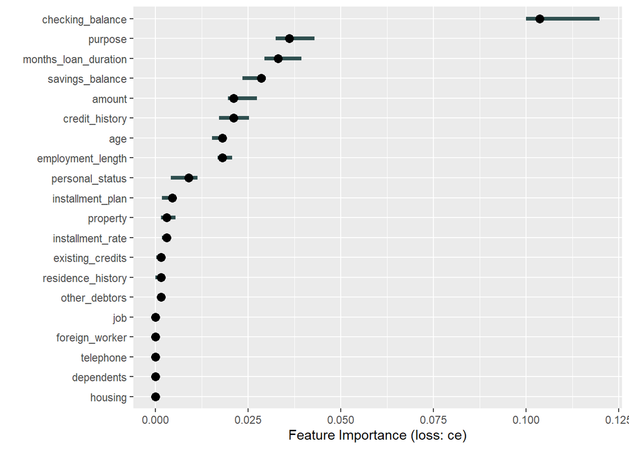

```r
plot(imp)
```

```r
imp$results
```

```
##                 feature importance.05  importance importance.95
## 1      checking_balance  0.1000000000 0.103603604   0.119819820
## 2               purpose  0.0324324324 0.036036036   0.042942943
## 3  months_loan_duration  0.0294294294 0.033033033   0.039339339
## 4       savings_balance  0.0234234234 0.028528529   0.029729730
## 5        credit_history  0.0171171171 0.021021021   0.025225225
## 6                amount  0.0195195195 0.021021021   0.027327327
## 7     employment_length  0.0168168168 0.018018018   0.020720721
## 8                   age  0.0153153153 0.018018018   0.019219219
## 9       personal_status  0.0042042042 0.009009009   0.011411411
## 10     installment_plan  0.0018018018 0.004504505   0.004504505
## 11     installment_rate  0.0018018018 0.003003003   0.004204204
## 12             property  0.0015015015 0.003003003   0.005405405
## 13        other_debtors  0.0015015015 0.001501502   0.001501502
## 14    residence_history  0.0000000000 0.001501502   0.001501502
```

[output cut: 27 more lines]

En la anterior tabla y en la gráfica, podemos observar las principales variables, destacando: checking_balance, purpose y months_loan_duration. Por otro lado, las variables que representan menos importancia, son las que estan más cercanas al valor 0, como: job, forengi_worker, telephone, etc

```r
print(rf)  # Muestra detalles del modelo
```

```
##
## Call:
##  randomForest(formula = default ~ ., data = train.data, ntree = 500)
##                Type of random forest: classification
##                      Number of trees: 500
## No. of variables tried at each split: 4
##
##         OOB estimate of  error rate: 24.17%
## Confusion matrix:
##     1  2 class.error
## 1 434 35  0.07462687
## 2 126 71  0.63959391
```

Vemos que el modelo tampoco mejora utilizando Random Forest

Tras ejecutar múltiples versiones de modelos de árboles de decisión, incluyendo C5.0 básico, C5.0 con Boosting, Random Forest y Árbol podado con rpart, hemos evaluado su rendimiento para la clasificación de clientes en riesgo de impago (Default = 2). Sin embargo, ninguno ha logrado mejorar significativamente el modelo original, ya que en ninguno se ha apreciado una mejora significativa en el porcentaje de error ni en la clasificacion de los clientes default = 2, teniendo una clasificación errónea considerable.

## 1.6 Conclusiones finales (25%)

Tras la implementación y evaluación de diversos modelos de clasificación para identificar clientes en riesgo de impago (Default = 2), se han obtenido insights clave sobre la eficacia de los métodos empleados y las limitaciones del conjunto de datos.

**Modelos probados**

Se han desarrollado tres enfoques principales con variaciones en los hiperparámetros:

[output not shown]

Utilizando Feature Importance en **randomForest**, se han identificado las variables que más influyen en la predicción del incumplimiento de pagos (default), siendo las variables más relevantes:

- checking_balance -> Impacto directo en la estabilidad financiera inicial del cliente.
- purpose -> Propósito para el cual se pide el crédito.
- months_loan_duration -> Duración del crédito.
- amount -> Cantidad solicitada afecta significativamente la probabilidad de impago.
- savings_balance -> Los ahorros de los clientes, también afectan signifiactivamente a la probabilidad de impago.

Podemos calcular las métricas de cada modelo como recall, precision y F1-score, lo que nos permitirá conocer la proporción de casos de impago que fueron correctamente identificados, con la precisión sabremos que proporción de casos el modelo predijo como impago y realmente lo fueron y con F1-score, tendremos el balance de precisión, útil si las clases están desbalanceadas.

```r
# creamos una función
calcular_metricas <- function(TP, FN, FP) {
  recall <- TP / (TP + FN)
  precision <- TP / (TP + FP)
  f1 <- 2 * ((precision * recall) / (precision + recall))

  return(c(
    Recall = round(100 * recall, 2),
    Precision = round(100 * precision, 2),
    F1_Score = round(100 * f1, 2)
  ))
}
```

```r
# Llamamos a la funcion para cada modelo

# C5.0 Básico
calcular_metricas(TP = 33, FN = 70, FP = 21)
```

```
##    Recall Precision  F1_Score
##     32.04     61.11     42.04
```

```r
# C5.0 Boosting (trials = 10)
calcular_metricas(TP = 43, FN = 60, FP = 22)
```

```
##    Recall Precision  F1_Score
##     41.75     66.15     51.19
```

```r
# C5.0 Boosting (trials = 100)
calcular_metricas(TP = 46, FN = 57, FP = 23)
```

```
##    Recall Precision  F1_Score
##     44.66     66.67     53.49
```

```r
# Validación cruzada (C5.0)
calcular_metricas(TP = 47, FN = 56, FP = 32)
```

```
##    Recall Precision  F1_Score
##     45.63     59.49     51.65
```

```r
# Árbol podado (rpart)
calcular_metricas(TP = 50, FN = 53, FP = 33)
```

```
##    Recall Precision  F1_Score
##     48.54     60.24     53.76
```

```r
# Random Forest
calcular_metricas(TP = 71, FN = 126, FP = 35)
```

```
##    Recall Precision  F1_Score
##     36.04     66.98     46.86
```

Podemos concluir nuestro análisis con las siguientes conclusiones:

Si priorizamos detectar a quienes no pagarán (impagos):

- El árbol podado (rpart) es el mejor, con mayor recall y F1-score.
- Muy buen compromiso entre precisión y sensibilidad.

Si quiermos precisión alta y un modelo más robusto (pero toleramos más falsos negativos):

- Considerar C5.0 con Boosting (trials = 100).

Evitaremos Random Forest si el foco es evitar dar crédito a quienes van a incumplir. Tiene buena precisión general, pero alto número de falsos negativos (126).